# Team 23 Final Project: Citi Bike in NYC

## Jiaxuan Alice Ji and Fuman Annie Xie

## Introduction

### Project Description

Our project aims to gain insights into the New York City Citi Bikesharing service, focusing on three key aspects: user demand, user type, and bike type. With the rising popularity of shared bikes as a means of commuting, particularly in the post-Covid era, our project is interested in investigating user demand, taking into account weather conditions and user profiles. Additionally, we aim to examine the different types of users, including members and casual riders, as well as the usage of different types of bicycles, such as classic and electronic. Through our analysis, we hope to provide valuable insights to the Bikesharing service provider, which can inform future business decisions and service improvements.

### Data

This project investigates the **trip data from Citi Bike in New York City from March 2022 to Febuary 2023**. There are 31,941,199 trips in total. Each entry has the start/end time and station, whether the user chose an electric bike or a a classic bike, whether the user was a member or a casual rider. We extract the date and weekday information from the start time. To enrich our dataset, we merged **weather** dataset (temperature, windspeed, rainy or snowy) on the date. Since we don't have detailed information about the riders, we merged **demographics** from each community district (median household income, the proportion of people having car-free commute, the average time people spend on commute, etc.) based on the start station location to our dataset in hope that these demographics can provide at least some information about the riders.

### Problem Summary

1. Predict daily bike demand based on weekday, weather information
2. Classify bike type based on trip details, weather information, and demographical features
3. Classify user type based on trip details, and demographical features

### Exploratory Data Analysis

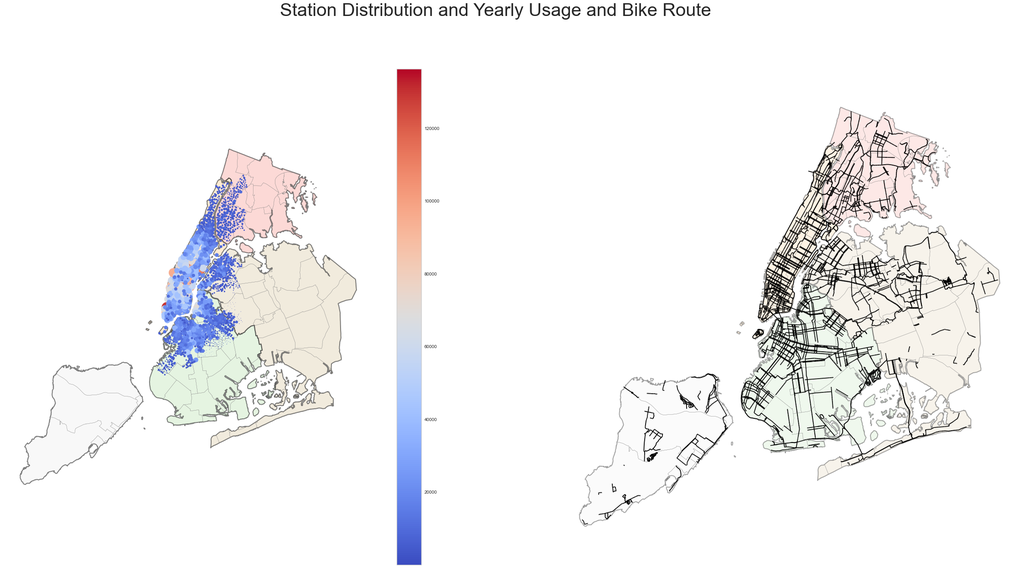

```python
# read shape files
boro_map = gpd.read_file('data/boro_shp/boro.shp')
cd_map = gpd.read_file('data/cd_shp/community_districts.shp')
bike_route = gpd.read_file('data/bike_route_shp/bikeroute.shp')

fig, ax = plt.subplots(1,2, figsize=(40,20))

boro_map.plot(ax = ax[0], column = 'boro_name', cmap = 'Pastel1', edgecolor = 'black' , linewidth = 2, alpha = 0.5)
cd_map.plot(ax = ax[0], color = 'none', edgecolor = 'grey')
stations_map.plot(ax = ax[0], column = 'yearly_use', cmap ='coolwarm', markersize = stations_map['yearly_use']/250,
                 legend = True)

boro_map.plot(ax = ax[1], column = 'boro_name', cmap = 'Pastel1', edgecolor = 'black' , linewidth = 2, alpha = 0.3)
cd_map.plot(ax = ax[1], color = 'none', edgecolor = 'grey')
bike_route.plot(ax = ax[1], color = 'black')

ax[0].set_axis_off();
ax[1].set_axis_off();
fig.suptitle("Station Distribution and Yearly Usage and Bike Route", fontsize = 40)

plt.show()
```

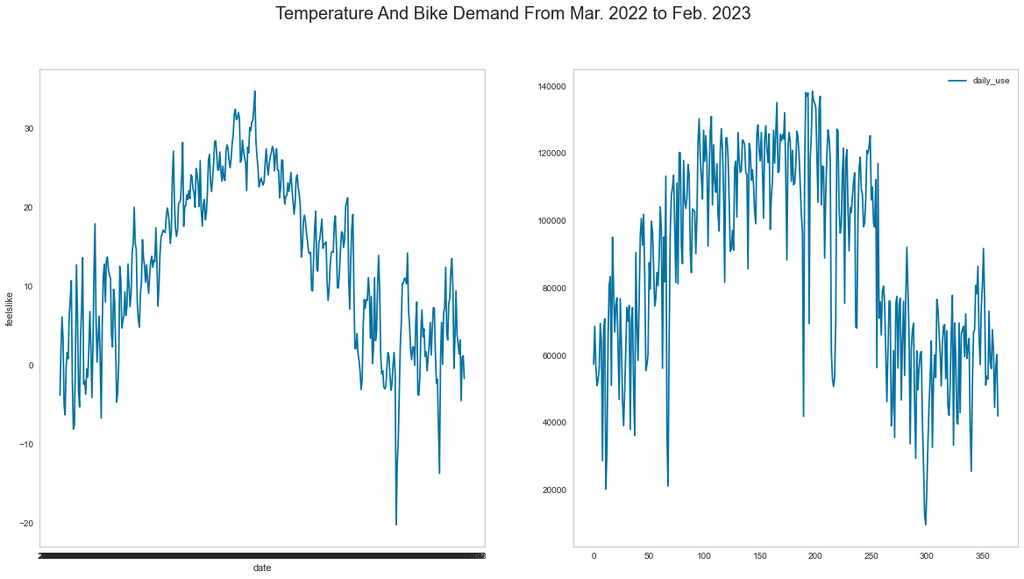

```python
daily_use.columns = ['daily_use']
fig, ax = plt.subplots(1,2,figsize = (20, 10))
sns.lineplot(data = weatherdata, x = "date", y = "feelslike", ax = ax[0])
sns.lineplot(data = daily_use, ax = ax[1])
ax[0].grid(False)
ax[1].grid(False)
fig.suptitle("Temperature And Bike Demand From Mar. 2022 to Feb. 2023", fontsize = 20)
plt.show()
```

## Problem 1: Bike Demand Prediction

For the first research question to predict bike demand, we choose linear, ridge and lasso regression.

#### Bonus Model: Decision Tree Regressor

```python
from sklearn.tree import DecisionTreeRegressor
dtr = DecisionTreeRegressor(random_state = 8)
param_dtr = {"max_depth" : [2, 3, 4, 5], "min_samples_leaf" : [1, 2, 3]}
tuning_dtr = GridSearchCV(dtr,                    # model
                      param_grid = param_dtr,   # hyperparameters
                      scoring='neg_mean_squared_error',        # metric for scoring
                      cv = 10)
tuning_dtr.fit(X_train_std, y_reg_train)

print("DTR best parameters: ", tuning_dtr.best_params_)
print("DTR best CV MSE: ", -tuning_dtr.best_score_)
```

```
DTR best parameters:  {'max_depth': 2, 'min_samples_leaf': 2}
DTR best CV MSE:  513525011.4907855
```

```python
import dtreeviz
feature_names = X_reg.columns
viz = dtreeviz.model(dtr, X_train_std, y_reg_train, target_name = "daily_use", feature_names = feature_names)
viz.view(scale = 1.6)
```

[figure not shown]

### Model Selection

We choose the model with the lowest CV MSE, which is lasso regression.

```python
print("Linear:     ", lr_reg_cv_error)
print("Best Ridge: ", CV_error_ridge)
print("Best Lasso: ", CV_error_lasso)
```

```
Linear:      473727682.65667737
Best Ridge:  471838482.0267619
Best Lasso:  466895126.6117247
```

### Model Performance Metrics

```python
best_lasso = Lasso(alpha = best_alpha_lasso)
best_lasso.fit(X_train_std, y_reg_train)
y_pred = best_lasso.predict(X_test_std)

print(pd.DataFrame({"Feature": X_reg.columns, "Coefficient": best_lasso.coef_}))
print("Train set R squared: ", best_lasso.score(X_train_std, y_reg_train))
print("Test set R squared:  ", best_lasso.score(X_test_std, y_reg_test))
print("Test set MSE:        ", mean_squared_error(y_reg_test, y_pred))
```

```
            Feature   Coefficient
0         windspeed   1358.056751
1         feelslike  19795.446264
2       rainy_snowy      0.000000
3   raw_weekday_Fri      0.000000
4   raw_weekday_Mon  -5509.917767
5   raw_weekday_Sat      0.000000
6   raw_weekday_Sun  -7459.023613
7  raw_weekday_Thur     -0.000000
8   raw_weekday_Tue     -0.000000
9   raw_weekday_Wed   2595.600110
Train set R squared:  0.4711344398005167
Test set R squared:   0.4302930421561053
Test set MSE:         607284742.0798445
```

### Conclusion and Discussion

To predict daily bike demand, we have trained linear, ridge and lasso regression. We utilized GridSearchCV to tune ridge and lasso. The best model is lasso with an alpha of 268.67. The R squared of the test set is 0.43, which means our model explained 43% of the variance in the target variable, which is not very good. But considering that we only have limited features, it's acceptable. In terms of coefficients, we can see that the predominant feature is 'feelslike', which is what we expected.

## Problem 2: Bike Type Classification

For the second research question to classify bicycle type, we use three methods, including Logistics Regression, KNN, and Random Forest.

For classification problems, since we have 32,000,000 entries, we take a subset to be able to run the models.

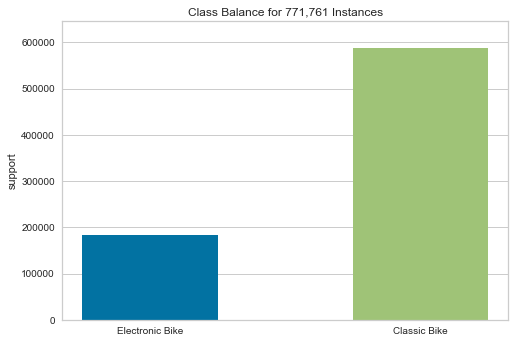

```python
from yellowbrick.target import ClassBalance
from sklearn.ensemble import RandomForestClassifier

y = trip['rideable_type']
X = trip[trip.columns.difference(['rideable_type'])]

visualizer = ClassBalance(labels=["Electronic Bike", "Classic Bike"])

visualizer.fit(y)        # Fit the data to the visualizer
visualizer.show()
```

#### Model 1: Logistics Regression

```python
lr = LogisticRegression(max_iter = 100000000)

parameters_lr = {
    'solver'  : ['lbfgs', 'liblinear','newton-cg','sag','saga'],
}
tuning_lr = GridSearchCV(lr,                    # model
                      param_grid = parameters_lr,   # hyperparameters
                      scoring='f1',        # metric for scoring
                      cv=10)

tuning_lr.fit(X_train_subset, y_train_subset)

pd.DataFrame(tuning_lr.cv_results_)
results_lr = pd.concat([pd.DataFrame(tuning_lr.cv_results_["params"]),pd.DataFrame(tuning_lr.cv_results_["mean_test_score"], columns=["f1"])],axis=1)
results_lr
```

|  | solver | f1 |
| --- | --- | --- |
| 0 | lbfgs | 0.575836 |
| 1 | liblinear | 0.575746 |
| 2 | newton-cg | 0.575675 |
| 3 | sag | 0.575786 |
| 4 | saga | 0.575686 |